# ML-midterm-project

### Midterm project - Kaggle exercise project

https://www.kaggle.com/c/house-prices-advanced-regression-techniques

Goals

- Get familar with Kaggle competition since our final project may be a real Kaggle competition.
- Practice on large data set
- Data quality checking, missing data imputation
- Feature selection. What's your rationals to choose those features.
- Create at least 5 new features and explain your reason for every new features.
- Use feature importance to help you choose 10 features
- Choose 3 ML algorithms we covered in the class to build your prediction models
- For each model you build, you will need to evaluate and show your effort to improve it.
- Your jupyter submission should be in an article quality. Do NOT print huge data set in the notebook. Use head(). Use plotting to visualize your analysis and results. Use markdown to write your comments.
- Your score is based on completeness on every step.
- Submit in HTML and ipynb format on canvas

## Load self-ddesigned help function

```python
import pandas as pd
import numpy as np

class MyPdToolBox:
    def __init__( self , ):
        pass
    def getColumns(self , df ):
        return df.columns
    def getRows(self , df ):
        return df.index
    def getDim(self ,df ):
        return df.shape
    def getByRowNum(self , df , rowNum ):
        return df.iloc[rowNum]

class MyNpToolBox:
    def __init__(self, ):
        pass

    # myNpToolBox.combineLeftRight(  [1,2,3] ,[4,5,6]  )
    # array([1, 2, 3, 4, 5, 6])
    def combineLeftRight( self , left , right ):
        return np.hstack( ( left , right ) )

    # myNpToolBox.combineTopButton(  [1,2,3] ,[4,5,6]  )
    # array([[1, 2, 3],
    #    [4, 5, 6]])
    def combineTopButton( self , top , button ):
        return np.vstack( ( top , button )  )

    # myNpToolBox.combineZipLeftRight(  [1,2,3] ,[4,5,6]  )
    # array([[[1, 4],
    #     [2, 5],
    #     [3, 6]]])
    def combineZipLeftRight( self , left , right ):
        return np.dstack( ( left , right ) )

    # myNpToolBox.getSplitedArrByNumberOfChunk(  [1,2,3,4,5,6] , 3  )
    # [array([1, 2]), array([3, 4]), array([5, 6])]
    def getSplitedArrByNumberOfChunk( self , arr , chunkNum ):
        return np.array_split( arr ,  chunkNum )

    # myNpToolBox.getIndexByValue(  [1,2,3,4,5,6]  , 3  )
    # (array([2]),)
    # will return array localtion
    def getIndexByValue( self , arr , value ):
        return np.where( np.array(arr) == value )

myPdToolBox = MyPdToolBox()
myNpToolBox = MyNpToolBox()
```

```python
import matplotlib.pyplot as plt
%matplotlib inline
```

```python
trainDf = pd.read_csv( "train.csv"  )
testDf  = pd.read_csv( "test.csv"  )
```

```python
print( "train shape" ,  trainDf.shape )
print( "test shape" ,  testDf.shape )
```

```
train shape (1460, 81)
test shape (1459, 80)
```

```python
def getNullPercent( df  ):
    df         =    ( df.isnull().sum()/len( df )*100)
    df         =    pd.DataFrame( df.sort_values( ascending=False ) )
    df.columns =    ["Percent"]
    df         =    df[ df["Percent"] != 0  ]
    return df

def getListContainHighNULL(  nullDf , percent  ):
    highNullList = myPdToolBox.getRows( nullDf[ nullDf["Percent"] >=  percent ] )
    lowNullList  = myPdToolBox.getRows( nullDf[ nullDf["Percent"] <  percent ]  )
    return  highNullList , lowNullList
#return list( zip(  nullPercentDict.keys() ,    nullPercentDict.values() ) )
```

```python
nullDf = getNullPercent( trainDf )
nullDf.head(19)
```

|  | Percent |
| --- | --- |
| PoolQC | 99.520548 |
| MiscFeature | 96.301370 |
| Alley | 93.767123 |
| Fence | 80.753425 |
| FireplaceQu | 47.260274 |
| LotFrontage | 17.739726 |
| GarageYrBlt | 5.547945 |
| GarageCond | 5.547945 |
| GarageType | 5.547945 |
| GarageFinish | 5.547945 |
| GarageQual | 5.547945 |
| BsmtFinType2 | 2.602740 |
| BsmtExposure | 2.602740 |
| BsmtQual | 2.534247 |
| BsmtCond | 2.534247 |
| BsmtFinType1 | 2.534247 |
| MasVnrArea | 0.547945 |
| MasVnrType | 0.547945 |
| Electrical | 0.068493 |

```python
highNullList , lowNullList = getListContainHighNULL( nullDf , 40 )
```

```python
highNullList
```

```
Index(['PoolQC', 'MiscFeature', 'Alley', 'Fence', 'FireplaceQu'], dtype='object')
```

```python
lowNullList
```

```
Index(['LotFrontage', 'GarageYrBlt', 'GarageCond', 'GarageType',
       'GarageFinish', 'GarageQual', 'BsmtFinType2', 'BsmtExposure',
       'BsmtQual', 'BsmtCond', 'BsmtFinType1', 'MasVnrArea', 'MasVnrType',
       'Electrical'],
      dtype='object')
```

```python
def handleDropColumn( df , highNullList ):
    # these column contain high amount of None
    df = df.drop( highNullList , axis = 1 )
    # id is not needed for evaluation
    df = df.drop( [ 'Id' ] ,  axis = 1 )
    return df

trainDf = handleDropColumn( trainDf , highNullList )
```

```python
def distNumOrStr( featurelist , df ):

    lowNullDict = dict()
    def isNan( x ):
            try:
                if(  math.isnan( x ) ):
                    return False
                return True
            except:
                return True
    for item in featurelist:
        tmp1 = df[item].to_numpy()
        try:
            tmp2 = type( tmp1[ list( map( isNan ,  tmp1   ) ) ].sum() )
        except:
            tmp2 = type('str')

        if( tmp2 == type('str')   ):
            lowNullDict[item] = "Categorical"
        else:
            lowNullDict[item] = "Numerical"
    return lowNullDict

# lowNullList     trainDf
lowNullArr = distNumOrStr( lowNullList , trainDf  )
lowNullArr
```

```
{'LotFrontage': 'Numerical',
 'GarageYrBlt': 'Numerical',
 'GarageCond': 'Categorical',
 'GarageType': 'Categorical',
 'GarageFinish': 'Categorical',
 'GarageQual': 'Categorical',
 'BsmtFinType2': 'Categorical',
 'BsmtExposure': 'Categorical',
 'BsmtQual': 'Categorical',
 'BsmtCond': 'Categorical',
 'BsmtFinType1': 'Categorical',
 'MasVnrArea': 'Numerical',
 'MasVnrType': 'Categorical',
 'Electrical': 'Categorical'}
```

```python
lowNullList
```

```
Index(['LotFrontage', 'GarageYrBlt', 'GarageCond', 'GarageType',
       'GarageFinish', 'GarageQual', 'BsmtFinType2', 'BsmtExposure',
       'BsmtQual', 'BsmtCond', 'BsmtFinType1', 'MasVnrArea', 'MasVnrType',
       'Electrical'],
      dtype='object')
```

### Fill the column which contain nan

```python
# so numerical value we will use mean to replace and categorical value we will replace with mode
def handleFillNa( featureDict , df ):
    for item in featureDict.keys():
        if( featureDict[ item ]  == "Numerical" ):
            df[ item ].fillna( df[ item ].median(), inplace=True)
        elif(   featureDict[ item ]  == "Categorical" ) :
            df[ item ].fillna( df[ item ].mode()[0], inplace=True)
    return df
trainDf = handleFillNa( lowNullArr , trainDf )
```

### Decode the categorical data

```python
from sklearn.preprocessing import LabelEncoder

def convertCategoricalToNumber( df ):
    for i in df.columns:
        le = LabelEncoder()
        df[i] = le.fit_transform(df[i])
    return df
trainDf  = convertCategoricalToNumber( trainDf )
```

## Split the data to features and targets

```python
def getFeatureAndTarget( df ):
    features = df.iloc[:,:-1]
    targets = df.iloc[:,-1]
    return features , targets
```

```python
features , targets = getFeatureAndTarget( trainDf )
```

```python
trainDf.shape
```

```
(1460, 75)
```

```python
features.shape
```

```
(1460, 74)
```

```python
targets.shape
```

```
(1460,)
```

```python
features.columns
```

```
Index(['MSSubClass', 'MSZoning', 'LotFrontage', 'LotArea', 'Street',
       'LotShape', 'LandContour', 'Utilities', 'LotConfig', 'LandSlope',
       'Neighborhood', 'Condition1', 'Condition2', 'BldgType', 'HouseStyle',
       'OverallQual', 'OverallCond', 'YearBuilt', 'YearRemodAdd', 'RoofStyle',
       'RoofMatl', 'Exterior1st', 'Exterior2nd', 'MasVnrType', 'MasVnrArea',
       'ExterQual', 'ExterCond', 'Foundation', 'BsmtQual', 'BsmtCond',
       'BsmtExposure', 'BsmtFinType1', 'BsmtFinSF1', 'BsmtFinType2',
       'BsmtFinSF2', 'BsmtUnfSF', 'TotalBsmtSF', 'Heating', 'HeatingQC',
       'CentralAir', 'Electrical', '1stFlrSF', '2ndFlrSF', 'LowQualFinSF',
       'GrLivArea', 'BsmtFullBath', 'BsmtHalfBath', 'FullBath', 'HalfBath',
       'BedroomAbvGr', 'KitchenAbvGr', 'KitchenQual', 'TotRmsAbvGrd',
       'Functional', 'Fireplaces', 'GarageType', 'GarageYrBlt', 'GarageFinish',
       'GarageCars', 'GarageArea', 'GarageQual', 'GarageCond', 'PavedDrive',
       'WoodDeckSF', 'OpenPorchSF', 'EnclosedPorch', '3SsnPorch',
       'ScreenPorch', 'PoolArea', 'MiscVal', 'MoSold', 'YrSold', 'SaleType',
       'SaleCondition'],
      dtype='object')
```

## The five features would better be OverallQual, LotArea, YearBuilt , Street, HouseStyle.

### From buyers' perspective, the housing quality would be put in the first place. Then they will care about the housing space, location, the year built , and style to see whether the housing fullfill their requirement.

## Find 10 Candidate Feature Based on Variance

```python
featuresVarDict = dict( features.var() )
featuresVarList =  list( zip( featuresVarDict.keys() , featuresVarDict.values() ) )
featuresVarList.sort(key= lambda x : x[1] , reverse=True)
candidateFeature = np.array( list(  map(  lambda x : x[0]  ,  featuresVarList[:10] ) ) )
```

```python
candidateFeature
```

```
array(['LotArea', 'GrLivArea', 'BsmtUnfSF', '1stFlrSF', 'BsmtFinSF1',
       'TotalBsmtSF', '2ndFlrSF', 'GarageArea', 'MasVnrArea',
       'WoodDeckSF'], dtype='<U11')
```

```python
topCorrelationTable =  ( trainDf.corr()[ candidateFeature  ] ).loc[ candidateFeature ]
```

```python
topCorrelationTable.head(2)
```

|  | LotArea | GrLivArea | BsmtUnfSF | 1stFlrSF | BsmtFinSF1 | TotalBsmtSF | 2ndFlrSF | GarageArea | MasVnrArea | WoodDeckSF |
| --- | --- | --- | --- | --- | --- | --- | --- | --- | --- | --- |
| LotArea | 1.000000 | 0.454594 | 0.080988 | 0.447255 | 0.204304 | 0.375820 | 0.196752 | 0.369772 | 0.197935 | 0.217749 |
| GrLivArea | 0.454594 | 1.000000 | 0.250020 | 0.505955 | 0.106696 | 0.394426 | 0.705183 | 0.481044 | 0.359757 | 0.236082 |

```python
def getHighCorrList( df ):
# df.columns    df.index
    returnList = []
    for colNum in range( ( df.shape)[1] ):
        for rowNum in range( ( df.shape)[0] ):
            tmp = (df[ df.columns[colNum] ]).loc[ df.index[rowNum] ]
            if ( ( tmp > 0.5 and tmp < 1  ) and  colNum < rowNum ) :
                returnList.append( { df.columns[colNum] : [ df.index[rowNum] , tmp ]  }   )
    return  returnList
highCorrelationList =  getHighCorrList( topCorrelationTable )
```

## The feature below has high correlation which means some of them aren't nessary for measuring.

```python
highCorrelationList
```

```
[{'GrLivArea': ['1stFlrSF', 0.5059550611927779]},
 {'GrLivArea': ['2ndFlrSF', 0.7051830769240625]},
 {'1stFlrSF': ['TotalBsmtSF', 0.8515603263731814]},
 {'1stFlrSF': ['GarageArea', 0.5021820609378967]},
 {'TotalBsmtSF': ['GarageArea', 0.5129313330810342]}]
```

## Now we use random forest to find the important features

```python
from sklearn.ensemble import RandomForestRegressor
from sklearn.model_selection import train_test_split
X_train, X_test, y_train, y_test = train_test_split( features, targets , test_size=0.3,random_state=101)
```

```python
model = RandomForestRegressor(random_state=1, max_depth=10)
```

```python
X_train.shape
```

```
(1022, 74)
```

```python
X_test.shape
```

```
(438, 74)
```

```python
model.fit( X_train , y_train )
```

```
RandomForestRegressor(max_depth=10, random_state=1)
```

```python
print('Accuracy of Salary classifier on training set: {:.2f}'
     .format(model.score( X_train ,  y_train )))
print('Accuracy of Salary classifier on test set: {:.2f}'
     .format(model.score(X_test , y_test )))
```

```
Accuracy of Salary classifier on training set: 0.98
Accuracy of Salary classifier on test set: 0.89
```

## top 10 important features based on random forest

```python
top10features =  list( map( lambda x : x[1] ,  list(reversed(sorted(zip(model.feature_importances_, features.columns.values))))[:10] ))
```

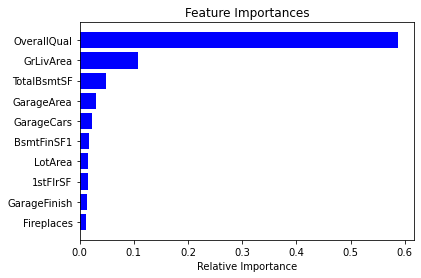

```python
importances = model.feature_importances_
indices = np.argsort(importances)[-10:]  # top 10 features
plt.title('Feature Importances')
plt.barh(range(len(indices)), importances[indices], color='b', align='center')
plt.yticks(range(len(indices)), [features.columns[i] for i in indices])
plt.xlabel('Relative Importance')
plt.show()
```

```python
features = features[top10features]
```

```python
top10features
```

```
['OverallQual',
 'GrLivArea',
 'TotalBsmtSF',
 'GarageArea',
 'GarageCars',
 'BsmtFinSF1',
 'LotArea',
 '1stFlrSF',
 'GarageFinish',
 'Fireplaces']
```

# Three ML Algo to build prediction model

```python
X_train, X_test, y_train, y_test = train_test_split( features, targets , test_size=0.3,random_state=101)
```

## Desision Tree

```python
from sklearn.tree import DecisionTreeRegressor
tree = DecisionTreeRegressor( max_depth = 10 ).fit( X_train ,  y_train )
```

```python
print('Accuracy of  classifier on training set: {:.2f}'
     .format(tree.score(X_train ,  y_train)))
print('Accuracy of  classifier on test set: {:.2f}'
     .format(tree.score(X_test , y_test )))
```

```
Accuracy of  classifier on training set: 0.98
Accuracy of  classifier on test set: 0.73
```

## We try to improve the score by measure the depth

```python
depthList = dict()
for depth in range( 1 , 15 ):
    tree = DecisionTreeRegressor( max_depth = depth ).fit( X_train ,  y_train )
    depthList[ depth ] = tree.score(X_test , y_test )
```

```python
depthList = list( zip( depthList.keys() , depthList.values() ) )
```

```python
depthList.sort( key = lambda x:x[1]   , reverse=True )
depthList
```

```
[(5, 0.7959582285879467),
 (6, 0.7905032037106084),
 (7, 0.7862247746517333),
 (8, 0.7840994923004144),
 (4, 0.7688897054665615),
 (10, 0.743323746709901),
 (14, 0.7404257529295749),
 (13, 0.7362863323408478),
 (11, 0.7330983702821299),
 (3, 0.731460302658403),
 (9, 0.7300188807135504),
 (12, 0.7271557476030492),
 (2, 0.6566836356211452),
 (1, 0.4935928163252148)]
```

### so the optimal depth for the Desision tree is 5

## Linear Regression

```python
from sklearn.linear_model import LinearRegression
linreg = LinearRegression().fit(X_train, y_train)
```

```python
print('Accuracy of  classifier on training set: {:.2f}'
     .format(linreg.score(X_train ,  y_train)))
print('Accuracy of  classifier on test set: {:.2f}'
     .format(linreg.score(X_test , y_test )))
```

```
Accuracy of  classifier on training set: 0.86
Accuracy of  classifier on test set: 0.84
```

##### try to improve using more features

```python
def tryMoreFeature( trainDf  ):
    featuresFull , targetsFull = getFeatureAndTarget( trainDf )
    X_train, X_test, y_train, y_test = train_test_split( featuresFull, targetsFull , test_size=0.3,random_state=101)
    linreg = LinearRegression().fit(X_train, y_train)
    print('Accuracy of  classifier on training set: {:.2f}'
         .format(linreg.score(X_train ,  y_train)))
    print('Accuracy of  classifier on test set: {:.2f}'
         .format(linreg.score(X_test , y_test )))
```

```python
tryMoreFeature( trainDf  )
```

```
Accuracy of  classifier on training set: 0.93
Accuracy of  classifier on test set: 0.88
```

## SVM

```python
from sklearn.svm import SVC
svc = SVC(kernel='linear'  , gamma='scale'  )
svc.fit( X_train, y_train )
```

```
SVC(kernel='linear')
```

```python
print('Accuracy of  classifier on training set: {:.2f}'
     .format(svc.score(X_train ,  y_train)))
print('Accuracy of  classifier on test set: {:.2f}'
     .format(svc.score(X_test , y_test )))
```

```
Accuracy of  classifier on training set: 0.96
Accuracy of  classifier on test set: 0.00
```

```python
from sklearn.svm import SVC
svc = SVC(kernel='poly'  , gamma='scale'  )
svc.fit( X_train, y_train )
```

```
SVC(kernel='poly')
```

```python
print('Accuracy of  classifier on training set: {:.2f}'
     .format(svc.score(X_train ,  y_train)))
print('Accuracy of  classifier on test set: {:.2f}'
     .format(svc.score(X_test , y_test )))
```

```
Accuracy of  classifier on training set: 0.18
Accuracy of  classifier on test set: 0.02
```

```python
from sklearn.svm import SVC
svc = SVC(kernel='rbf'  , gamma='scale'  )
svc.fit( X_train , y_train )
```

```
SVC()
```

```python
print('Accuracy of  classifier on training set: {:.2f}'
     .format(svc.score(X_train ,  y_train)))
print('Accuracy of  classifier on test set: {:.2f}'
     .format(svc.score(X_test , y_test )))
```

```
Accuracy of  classifier on training set: 0.04
Accuracy of  classifier on test set: 0.01
```

```python
from sklearn.naive_bayes import GaussianNB
model = GaussianNB(  )
model.fit(X_train, y_train)
```

```
GaussianNB()
```

```python
print('Accuracy of  classifier on training set: {:.2f}'
     .format(model.score(X_train ,  y_train)))
print('Accuracy of  classifier on test set: {:.2f}'
     .format(model.score(X_test , y_test )))
```

```
Accuracy of  classifier on training set: 0.55
Accuracy of  classifier on test set: 0.01
```

# Try to improve using support vector regressor instead of classifier

```python
from sklearn.svm import SVR
svrs = [SVR(kernel='linear', gamma='scale'), SVR(kernel='poly', gamma='scale'), SVR(kernel='rbf', gamma='scale')]
for model in svrs:
    model.fit( X_train , y_train )
kernalModels = ['linear', 'poly' ,'rbf' ]
for model , kernalModel in zip(svrs , kernalModels):
    print( f' Kernal Model : {kernalModel} ' )
    print('Accuracy of  classifier on training set: {:.2f}'
     .format(model.score(X_train ,  y_train)))
    print('Accuracy of  classifier on test set: {:.2f}'
         .format(model.score(X_test , y_test )))
    print("\n")
```

```
 Kernal Model : linear
Accuracy of  classifier on training set: 0.86
Accuracy of  classifier on test set: 0.84


 Kernal Model : poly
Accuracy of  classifier on training set: 0.63
Accuracy of  classifier on test set: 0.57


 Kernal Model : rbf
Accuracy of  classifier on training set: 0.52
Accuracy of  classifier on test set: 0.52
```